# Lab-02 Part B: The Eight Step Process®

Hazardous Materials: Managing the Incident

# The Eight Step Process®

**SHM 377: Hazardous Materials Management**

**Central Washington University**

**Professor Yoni Rodriguez**

*Hazardous Materials: Managing the Incident*

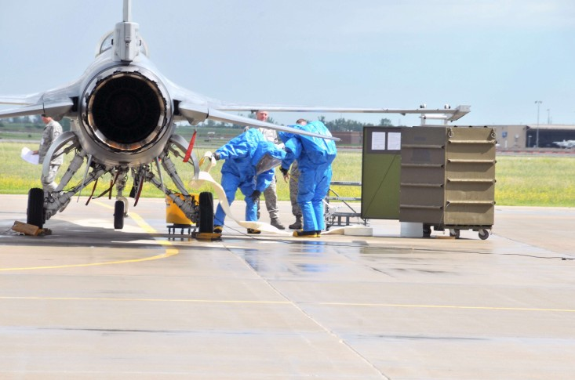

Colorado Air National Guard personnel conducting an F-16 hydrazine leak response training exercise at Buckley Air Force Base, Aurora, Colorado, July 2008.

**Figure 1.** Hazardous materials response training involving an F-16 aircraft.

*Source: U.S. Air Force, 140th Wing, “Training for worst case scenario,” July 12, 2008.*

## The Eight Step Process®

The Eight Step Process® outlines the basic tactical functions that need to be evaluated and implemented at hazmat incidents. Also, the Eight Step Process® is widely used throughout the country by government and private sector hazmat response teams.

On-scene response operations must always be based on a structured and standardized system of protocols and procedures. Regardless of the nature of the incident and response, a standardized procedure will bring consistency to the incident. If the situation may involve hazmats or weapons of mass destruction (WMD), standardized tactical response procedures help minimize the risk of exposure to all responders.

Like all standard operating procedures (SOPs), the Eight Step Process® should be seen as a flexible guideline, not a rigid rule. Individual departments and agencies should decide what works best for them.

## Benefits of the Eight Step Process®

The Eight Step Process® offers several benefits:

- **Recognizes the scale of most incidents:** Most incidents involving hazmats are minor and involve limited quantities.
- **Builds on initial response actions:** Builds on the action of first responding units and helps to identify the roles and responsibilities of each level of response.
- **Provides flexibility:** A flexible management system that expands as the scope and magnitude of the incident grows.
- **Establishes consistency:** Provides a consistent management structure, no matter what class of hazmats are involved.

## The Eight Tactical-Level Functions

There are eight basic tactical-level functions that must be evaluated at emergencies that involve or may involve hazmats or WMD agents.

These functions usually follow an implementation timeline at the incident:

1. **Site management and control**
2. **Identify the problem**
3. **Hazard assessment and risk evaluation**
4. **Select personal protective clothing and equipment**
5. **Information management and resource coordination**
6. **Implement response objectives**
7. **Decontamination (decon) and clean-up operations**
8. **Terminate the incident**

## Step 1: Site Management and Control

### Function

Site management and control involves **managing and securing the physical layout of the incident**.

You cannot safely and effectively manage an incident if you do not control the scene. Site management and control is critical for the overall success of the response. It is the foundation of all subsequent response functions, strategies, and tactics.

### Goal

**Establish the playing field** so that all subsequent response operations are implemented safely and effectively.

### Checklist

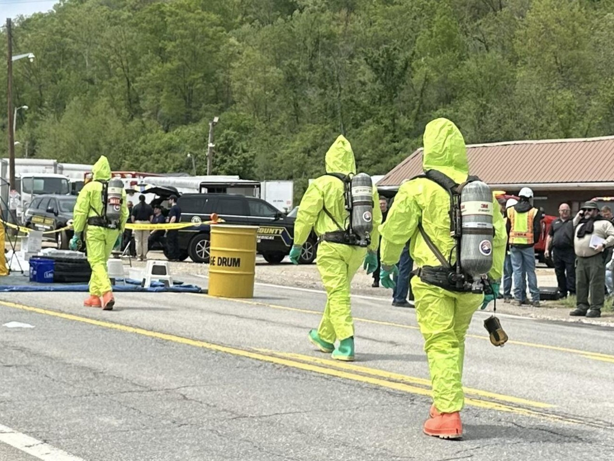

Initial approach to a hazardous materials incident scene.

**Initial approach to the incident scene**

- Avoid committing or positioning personnel in a hazardous position.
- Assess the situation first and have an escape route in case conditions suddenly deteriorate.

[figure not shown]

Incident command operations at a hazardous materials emergency.

**Incident command**

- Establish command of the incident and establish an incident command post (ICP).
- If other public safety units are already on scene, make sure operations are coordinated and unified.

[figure not shown]

Staging and perimeter control during a hazardous materials response.

**Staging and perimeter control**

- Establish a staging area (Level I, II) for additional responding equipment and personnel.
- Establish an isolation perimeter (i.e., outer perimeter) to isolate the area and deny entry.
- Establish access control and traffic control points.
- Restrict emergency site access to authorized essential personnel only.
- All nonessential personnel should be isolated from the problem.
- Isolation perimeters should include areas of land, water, and air.

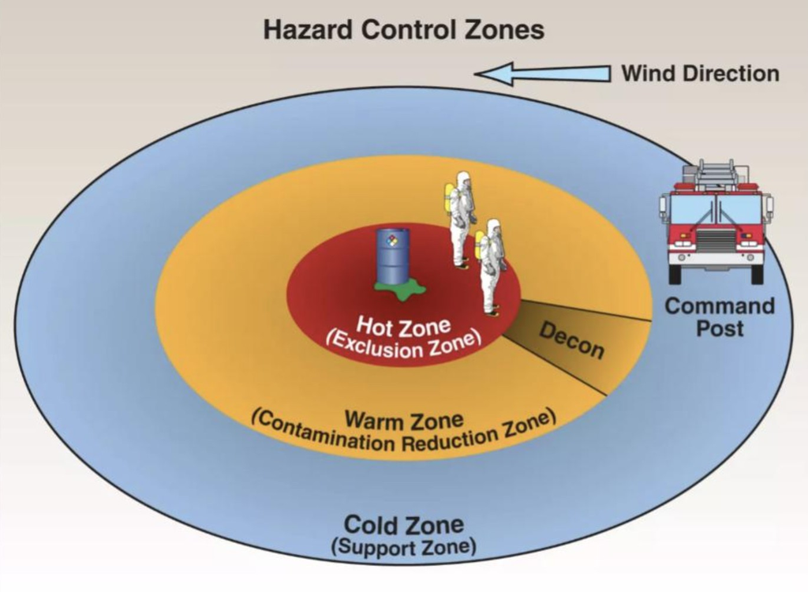

Establishing the hot zone at a hazardous materials incident.

**Hot zone establishment**

- Establish a hot zone or inner perimeter as the “playing field.”
- Identify and communicate to all personnel the location of the hot zone.
- Methods of identifying the restricted area include visible landmarks, barricade tape, and traffic cones.

[figure not shown]

Hazardous materials responders wearing personal protective equipment.

**Personal protective equipment**

- Enter the area only with the appropriate level of respiratory and skin protection for the hazards present.
- If victims are down, self-contained breathing apparatus (SCBA) is the minimum level of respiratory protection for initial emergency response operations.
- Depending on the situation and materials involved, structural firefighting clothing may not provide sufficient personal protection.

[figure not shown]

Public protective actions during a hazardous materials emergency.

**Public protective actions**

- If civilians are injured and you suspect personal contamination, isolate all personnel until emergency decon can be established.
- Initiate public protective actions.

**NoteCaution**

Emergency responders must be aware that certain chemical releases can travel throughout the scene and impact response routes.

Some chemicals can create vapor clouds that could be mistaken for fog or other normal weather and environmental conditions (e.g., anhydrous ammonia, liquefied petroleum gas, or LPG).

**The danger area may extend beyond the visible vapor cloud.**

**ImportantOperational Considerations**

- **Establish the playing field:** Site management establishes the playing field for the players (responders) and the spectators (everyone else).
- **Initial response timeline:**
  - The first 10 minutes of the incident determines operations for the next 60 minutes.
  - The first 60 minutes determines operations for the next 8 hours.
- **Maintain manageable boundaries:** Don’t attempt to establish an isolation perimeter larger than responders can effectively secure and control. A smaller, well-controlled perimeter may be more effective than a larger, poorly controlled one.
- **Remember the basics:** The more time, distance, and shielding between you and the material, the lower the risk will be. Don’t get the stuff on you!
- **Emergency evacuation:** Designate an emergency evacuation signal and identify rally points for emergency evacuation.
- **Hot zone operations:** Remember the first law of hot zone operations when dealing with hazardous materials. To play in the game you must:
  - Be trained to play.
  - Be dressed to play.
  - Have a buddy system with a backup capability (minimum of two-in/two-out).
  - Have decon established.
  - Coordinate with command and safety.

## Step 2: Identify the Problem

### Function

Identify the **scope and nature of the problem**. This includes:

- Recognition, identification, and verification of the hazmat/WMD involved in the incident.
- Type of container, as applicable.
- Exposures.

Methods of identification include:

- Analyzing container shapes, markings, labels and placards, and facility documents (e.g., pre-incident plans, Tier 2 reporting forms, Safety Data Sheets, or SDS).
- Using monitoring and detection equipment.
- Using the senses (i.e., physical observations, smell, reports from victims, etc.).

Responders should remember that even when the hazardous substances have been initially identified, **the information should always be verified**

### Goal

**Identify the scope and nature of the problem**, including the type and nature of hazardous materials involved.

### Checklist

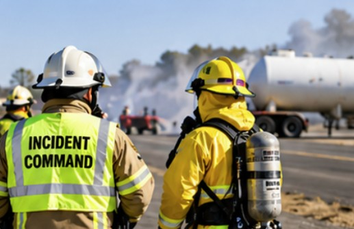

Responders surveying a hazardous materials incident scene.

**Survey the incident**

- Identify the nature and severity of the immediate problem, including:
  - Recognition, identification, and verification of the material(s) involved.
  - Type of container involved.
  - Any potential or existing life hazards.
- If multiple problems exist, prioritize them and make independent assignments.

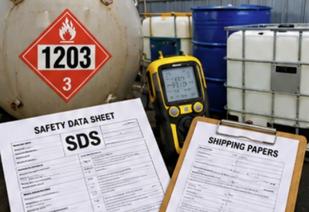

Hazardous materials identification clues, including placards, labels, shipping papers, and monitoring equipment.

**Clues for identifying hazardous materials**

- Occupancy and location.
- Container shapes.
- Markings and colors.
- Placards and labels.
- Shipping papers or facility documents.
- Monitoring and detection equipment.
- Senses, including physical observations, smell, and so on.

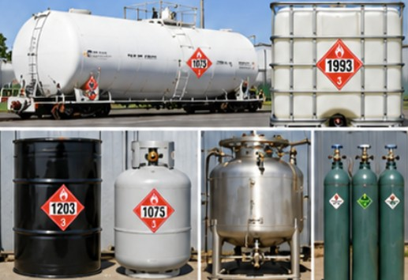

Different hazardous materials containers illustrating bulk and nonbulk storage, pressure vessels, and container configurations.

**Container characteristics**

Factors to consider in assessing the type of container involved include:

- Bulk versus nonbulk.
- Pressurized versus nonpressurized.
- Number of compartments.
- Material(s) of construction.
- Container valves, piping, and pressure relief devices.

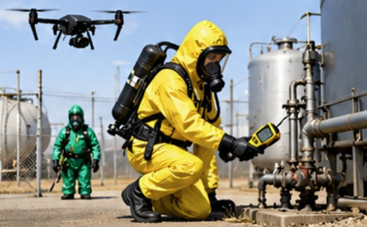

Hazardous materials reconnaissance involving protective equipment, monitoring instruments, and incident assessment.

**Reconnaissance**

- Conduct offensive or defensive reconnaissance (recon), as necessary, to gather intelligence on the situation.

**ImportantOperational Considerations**

- **A problem well defined is half solved.**
- **Verify initial information:** Assume initial information may be incomplete or incorrect. Always verify your initial information.
- **Conduct reconnaissance operations:** Recon can include:
  - **Defensive Recon:** Objective is to obtain information on site layout, containers, physical hazards, access, and other related conditions from beyond the inner perimeter. This is normally obtained through threat assessments, interviews, physical observations, use of unmanned aerial vehicles (UAVs), and so on.
  - **Offensive Recon:** Objective is to obtain intelligence and incident information by physically entering the inner perimeter. At incidents that involve both hazmat and explosive risks, this may be a joint-entry operation with both bomb squad and hazmat personnel to conduct monitoring, sampling, and video or photo documentation for analysis or evidence.
- **Be alert for secondary events and improvised explosive devices (IEDs).** IED clues can include:
  - Abandoned container out of place for the surroundings.
  - Obvious explosive device components, such as batteries, timers, blasting caps, charges, and wires taped to containers.
  - Trip wires, motion sensors, or partially exploded devices.
  - Unusual or foreign devices attached to hazmat containers, especially liquefied and compressed gas cylinders, flammable liquid containers, and bulk storage tanks and vessels.
  - Unattended vehicles not appropriate to the immediate environment.

## Step 3: Hazard Assessment and Risk Evaluation

### Function

This is **the most critical function that emergency responders perform**.

The primary objective of risk evaluation is to determine:

1. **Whether responders should intervene.**
2. **What strategies and tactics should be used to control the problem.**

It is critical to get this right. If you do not have the expertise to do this adequately, get help from someone who does (e.g., local hazardous materials response teams [HMRTs] and product/container technical specialists).

### Goal

**Assess the hazards present, evaluate the level of risk, and develop an incident action plan (IAP)** to make the problem go away.

### Checklist

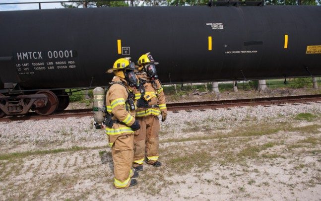

Hazardous materials responders assessing the hazards at an incident scene.

**Assess the hazards**

- Assess the hazards posed by the problem, including:
  - Health hazards.
  - Physical hazards.
  - Chemical hazards.
  - Weapons.
  - Other hazards.

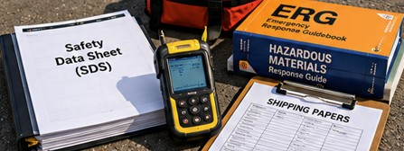

Safety Data Sheets, technical reference manuals, shipping documents, and hazardous materials detection equipment.

**Collect and evaluate hazard information**

Collect, prioritize, and manage hazard data and information from all sources, including:

- Technical reference manuals.
- Technical information sources.
- Hazmat databases.
- Technical information specialists.
- Safety Data Sheets (SDS).
- Monitoring and detection equipment.

[figure not shown]

Hazardous materials personnel consulting technical information centers and emergency response resources.

**Consult technical information centers**

Primary technical information centers available to public safety personnel include:

- CHEMTREC: (800) 424-9300.
- National Response Center (NRC), which serves as the federal single point of contact for accessing federal assistance.
- State single point of contact.
- Product or container specialists.
- State and regional poison control centers.

[figure not shown]

Hazardous materials container behavior illustrating stress, breach, release, engulfment, impingement, and harm.

**Evaluate hazardous materials behavior**

Air monitoring and the General Hazmat Behavior Model are critical in implementing a risk-based response process.

Understand the relationship and behaviors between the container and the hazmat(s) involved:

- Stress.
- Breach.
- Release.
- Engulf.
- Impingement/contact.
- Harm.

**NoteUnderstanding Impingement**

In hazmat operations, **impingement** is **the direct contact made by a released hazardous material with people, property, or the environment**.

It is measured by duration and categorized into short-term (seconds to hours), medium-term (days to months), and long-term (months to years) contact.

**Duration Categories**

- **Short-Term Impingement:** Lasts from seconds to hours; typically involves immediate acute exposure or rapid-release events.
- **Medium-Term Impingement:** Lasts from days to months; involves ongoing contamination or residual environmental presence.
- **Long-Term Impingement:** Lasts from months to years (or generations); involves deep soil, groundwater, or structural integration.

*Source: [Event — Impinge: Hazmat Behavior Model](https://vabeachfireacademy.blogspot.com/2017/01/event-impinge-hazmat-behavior-model.html).*

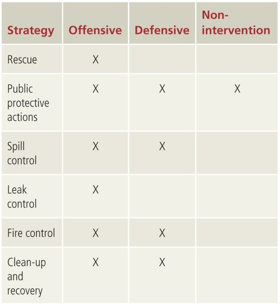

**Develop the incident action plan (IAP)**

Based on the risk evaluation process, develop your IAP.

Determine whether the incident should be handled offensively, defensively, or by nonintervention.

Remember that **offensive tactics increase the risks to emergency responders**.

- **Offensive mode/tactics:** Require responders to control or mitigate the emergency from within the area of high risk.
- **Defensive mode/tactics:** Permit responders to control or mitigate the emergency from outside the area of highest risk.
- **Nonintervention mode/tactics:** Implement a passive response posture until additional personnel or equipment arrive, or allow the fire to burn itself out.

**ImportantOperational Considerations**

- **Focus on what you can change:** Focus on the things you can change and that will have a positive impact on the outcome.
- **Evaluate the value of intervention:** Every incident will have an outcome, with or without your help. If you cannot change the outcome in a positive way, why get involved? Doing nothing and letting the incident take its course without intervention may be a viable option.
- **Balance risk and potential benefit:** There is nothing wrong with taking a risk. If there is much to be gained, there is much to be risked. If there is little to be gained, then little should be risked.
- **Be a risk evaluator:** When hazmats are involved, public safety personnel should see their roles as risk evaluators rather than risk takers. Good risk evaluators come home. Bad ones don’t.
- **Hour-one priorities within the IAP:**
  - Establish site management and control.
  - Identify the materials/agents involved.
  - Ensure the safety of all personnel from all hazards.
  - Ensure personal protective equipment (PPE) is appropriate for the hazards.
  - Initiate strategies and tactics to accomplish initial rescue, decon, medical, and public protective action needs.
- **Preserve potential evidence:** If criminal activities are involved (e.g., terrorism incidents), maintain the integrity of potential evidence.
- **Remember the PACE model of planning:**
  - **Primary:** Primary plan.
  - **Alternate:** Alternate plan.
  - **Contingency:** Contingency plan(s) based upon contingent scenarios.
  - **Emergency:** Emergency plan if responders must immediately evacuate the area.

## Step 4: Select Personal Protective Clothing and Equipment

### Function

Based on the results of the hazard and risk evaluation process, **select the proper level of personal protective clothing and equipment**.

Two primary types of personal protective clothing used at hazmat incidents are:

- Structural firefighting protective clothing.
- Chemical-protective clothing.

### Goal

**Ensure all emergency response personnel have the appropriate level of personal protective clothing and equipment (skin and respiratory protection)** for the expected tasks.

### Checklist

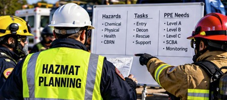

Hazmat personnel evaluating hazards, response tasks, and personal protective equipment requirements.

**Evaluate PPE selection factors**

The selection of personal protective clothing will depend on the hazards and properties of the materials involved and the response objectives to be implemented (i.e., offensive, defensive, or nonintervention).

In evaluating the use of specialized protective clothing, the following factors must be considered:

- **Hazards:** The hazard to be encountered, including the specific tasks to be performed. If victims are present, their signs and symptoms can provide clues that will influence the selection of PPE.
- **Tasks:** The tasks to be performed (e.g., entry, decon, support).
- **Protection:** The level and type of specialized protective clothing to be used.
- **Responder capabilities:** The capabilities of the individual(s) who will use the PPE in a hostile environment. Remember, specialized protective clothing places a great deal of both physiological and psychological stress on the wearer.

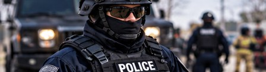

Responder wearing ballistic-protective clothing, including a protective vest and helmet.

**Ballistic-protective clothing**

- Protects against specific ballistic threats.
- Helps absorb the impact and/or reduce or stop penetration of bullets and steel fragments from handheld weapons and exploding munitions.

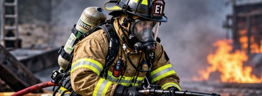

Firefighter wearing structural firefighting protective clothing and self-contained breathing apparatus.

**Structural firefighting protective clothing**

Includes:

- Helmet.
- Fire-retardant hood.
- Turnout coat and pants.
- Personal alert safety system (PASS device).
- Gloves.

**Positive-pressure self-contained breathing apparatus (SCBA)** is the minimum level of respiratory protection described for this ensemble.

[figure not shown]

Hazmat responder wearing fully encapsulating chemical vapor-protective clothing.

**Chemical vapor-protective clothing**

Specialized chemical-protective clothing used with air-supplied respiratory protection devices.

- Offers a sealed, integrated level of full-body protection from hostile environments.
- Primarily designed to protect against chemical gases and vapors.
- Provides total-body splash protection.

It may also be referred to as **EPA Level A chemical-protective clothing** or **NFPA 1991-compliant clothing**.

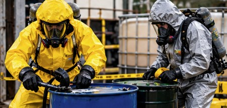

Hazmat responders wearing chemical splash-protective clothing with respiratory protection.

**Chemical splash-protective clothing**

Specialized protective clothing that protects against chemical liquid splashes but not against chemical vapors or gases.

It is mainly designed to provide personal protection against:

- Liquid splashes.
- Solids.
- Dusts.
- Particles.

It can be found in both single- and multipiece garment ensembles.

It is also called:

- **EPA Level B chemical-protective clothing** when air-supplied respiratory protection is provided.
- **EPA Level C chemical-protective clothing** when air-purifying respirators (APR) are provided.

Its design and chemical resistance may also be referred to as **NFPA 1992- or NFPA 1994-compliant clothing**, depending on the garment, its design, and chemical resistance.

**ImportantOperational Considerations**

- **Verify appropriate PPE:** Ensure that all emergency response personnel are using the proper protective clothing and equipment for the present hazards.
- **CBRN protection:** If the incident involves chemical, biological, radiological, and nuclear (CBRN) agents, ensure both skin and respiratory protection provide the required level of personal protection.
- **Avoid unsafe positioning:** Do not place personnel in an unsafe emergency situation or location.
- **Request additional resources early:** Order additional personnel, specialized equipment, and technical expertise early in the incident. If you are unsure of your incident needs, call for the highest level of assistance available. Do not wait to call for emergency assistance. It is always better to have too much than not enough.
- **Limitations of structural firefighting clothing:** Remember that structural firefighting protective clothing is not designed to protect against chemical hazards.
- **Chemical and thermal protection:** With some notable exceptions, it can be hard to effectively combine chemical and thermal protection.
- **Heat stress:** Wearing any type and level of impermeable protective clothing creates the potential for heat stress injuries.
- **Last line of defense:** Personal protective clothing is not your first line of defense. **It is your last line of defense!**

## Step 5: Information Management and Resource Coordination

### Function

Refers to the proper **management, coordination, and distribution of all relevant data and information within the Incident Command System (ICS)** at the scene.

This function cannot be effectively accomplished unless a unified ICS organization is in place.

The ability to determine the incident factors involved, which functions of the Eight Step Process® have been completed, what additional information must be obtained, and what incident factors remain unknown are especially important.

### Goal

**Quickly and efficiently coordinate and distribute all relevant data, information, and resources** among all of the players.

### Checklist

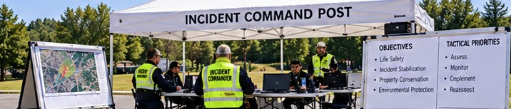

Incident command post established in a safe location away from immediate hazards.

**Confirm incident command post (ICP) safety**

- Confirm the ICP is in a safe area.

[figure not shown]

Senior representatives from fire, police, EMS, and EPA coordinating through unified command.

**Establish unified command and agency coordination**

- Confirm that:
  - A unified command organization is in place.
  - All assisting and cooperating agencies are represented directly or through the liaison officer.

[figure not shown]

**Expand the Incident Command System (ICS)**

- Expand the ICS and create additional branches, divisions, or groups within the operations section, as needed.

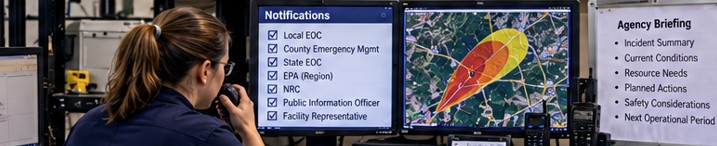

Emergency management personnel coordinating notifications and sharing incident information.

**Coordinate notifications and information sharing**

- Ensure all appropriate internal and external notifications have been made.
- Coordinate information and brief other agencies as needed.

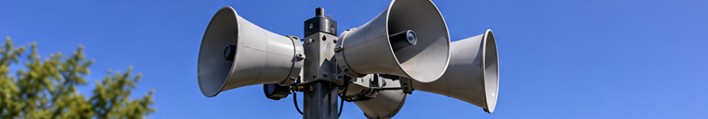

Outdoor emergency warning siren used to communicate emergency notifications and orders.

**Communicate safety procedures and emergency orders**

- Ensure safety procedures are part of all tactical briefings.
- Confirm emergency orders and take steps to make sure they are fully understood and correctly followed.
- Keep strict control of the situation.

[figure not shown]

Hazardous materials detection instruments and unmanned aerial vehicles used to monitor incident conditions.

**Monitor incident progress and coordinate additional resources**

- Make sure there is continuing progress toward solving the emergency.
- Do not wait to call for additional assistance if conditions appear to be deteriorating.
- If activated, regularly update the local/facility emergency operations center (EOC).

**NoteIncident Command Post (ICP) Considerations**

Personnel not directly involved in the overall command and control of the incident should be removed from the ICP area.

**ImportantOperational Considerations**

- **Secure incident response areas:** Consider the security of the ICP and all other incident response areas (e.g., staging, rehabilitation).
- **Plan ahead:** Don’t look unprepared because you didn’t have a plan.
- **Communicate problems early:** Bad news doesn’t get better with time. The earlier you know about a problem and communicate that information, the sooner you can start to fix it. Don’t let the incident commander be the last to know!
- **Prevent freelancing:** Don’t allow external resources to freelance or develop their own plan. Freelancing can happen at both the individual and organizational levels.
- **Establish the planning section early:** Don’t let your lack of a planning section become the Achilles’ heel of your response. Establish the planning section early, especially if the incident has the potential to become a campaign event.
- **Activate logistics when needed:** Operations may win battles, but logistics wins wars. Incidents that have specialized or substantial resource needs require the logistics section to be activated as early as possible.